# Lex Fridman

```python
data =open ("tweets.txt").read()
```

We've imported the data already, so lets start by doing a bit of visualization. There are a couple of ways I'd like to look at this first is through a word cloud and then the second is going to be a count of the most used words.

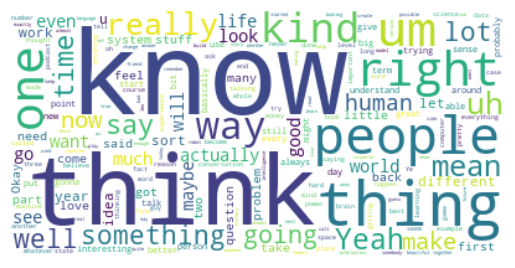

```python
import matplotlib.pyplot as plt
from wordcloud import WordCloud

word_cloud2 = WordCloud(collocations = False, background_color = 'white').generate(data)
plt.imshow(word_cloud2, interpolation='bilinear')

plt.axis("off")

plt.show()
```

Okay so I'm already starting to notice a problem but lets address that in a minute

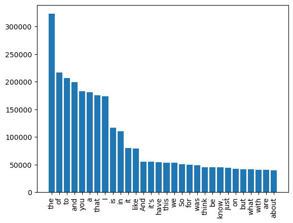

```python
with open('tweets.txt', 'r') as f:
    text = f.read()
    words = text.split()

# frequency of words
word_counts = {}
for word in words:
    if word in word_counts:
        word_counts[word] += 1
    else:
        word_counts[word] = 1

# sort the words
sorted_word_counts = sorted(word_counts.items(), key=lambda x: x[1], reverse=True)

# 30 most common words
most_common_words = sorted_word_counts[:30]

# words and frequencies into lists to plot
words = [x[0] for x in most_common_words]
frequencies = [x[1] for x in most_common_words]
plt.bar(words, frequencies)
plt.xticks(rotation=90)
plt.show()
```

https://en.wiktionary.org/wiki/Wiktionary:Frequency_lists :For the 100 most common words

```python
import csv

with open('100.csv', 'r', encoding='utf-8') as f:
    reader = csv.reader(f)
    words_to_remove = [row[0] for row in reader]

with open('tweets.txt', 'r', encoding='utf-8') as f:
    text = f.read()

words = text.split()

filtered_words = [word for word in words if word not in words_to_remove]

filtered_text = ' '.join(filtered_words)

with open('filtered_text.txt', 'w', encoding='utf-8') as f:
    f.write(filtered_text)
```

Sick. So now lets using that new file filtered_text use that for our graphs again.

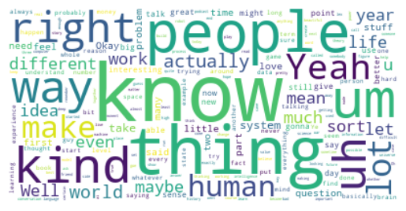

```python
data =open ("filtered_text.txt").read()

word_cloud2 = WordCloud(collocations = False, background_color = 'white').generate(data)
plt.imshow(word_cloud2, interpolation='bilinear')

plt.axis("off")

plt.show()
```

That looks better but lets see what our most common words look like I still see a few key words that may cause issues.

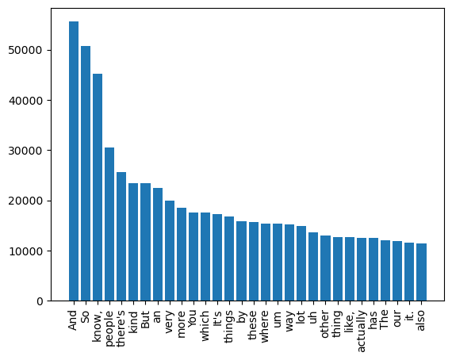

```python
with open('filtered_text.txt', 'r') as f:
    text = f.read()
    words = text.split()

# frequency of words
word_counts = {}
for word in words:
    if word in word_counts:
        word_counts[word] += 1
    else:
        word_counts[word] = 1

# sort the words
sorted_word_counts = sorted(word_counts.items(), key=lambda x: x[1], reverse=True)

# 30 most common words
most_common_words = sorted_word_counts[:30]

# words and frequencies into lists to plot
words = [x[0] for x in most_common_words]
frequencies = [x[1] for x in most_common_words]
plt.bar(words, frequencies)
plt.xticks(rotation=90)
plt.show()
```

```python
with open('1000.csv', 'r', encoding='utf-8') as f:
    reader = csv.reader(f)
    words_to_remove = [row[0] for row in reader]

with open('filtered_text.txt', 'r', encoding='utf-8') as f:
    text = f.read()

words = text.split()

filtered_words = [word for word in words if word not in words_to_remove]

filtered_text = ' '.join(filtered_words)

with open('filtered_text2.txt', 'w', encoding='utf-8') as f:
    f.write(filtered_text)
```

So lets try this again Starting with our bar graphs

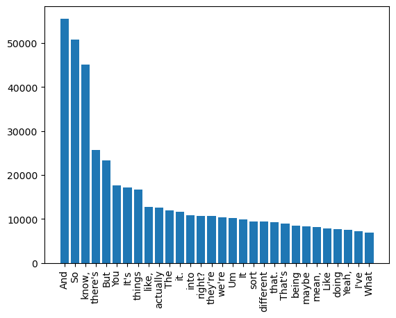

```python
with open('filtered_text2.txt', 'r') as f:
    text = f.read()
    words = text.split()

# frequency of words
word_counts = {}
for word in words:
    if word in word_counts:
        word_counts[word] += 1
    else:
        word_counts[word] = 1

# sort the words
sorted_word_counts = sorted(word_counts.items(), key=lambda x: x[1], reverse=True)

# 30 most common words
most_common_words = sorted_word_counts[:30]

# words and frequencies into lists to plot
words = [x[0] for x in most_common_words]
frequencies = [x[1] for x in most_common_words]
plt.bar(words, frequencies)
plt.xticks(rotation=90)
plt.show()
```

Right... So lets start removing the most commmon words based on specifically the check we're doing now. We'll go back to using filtered_text.txt that removed the 100 most common words and not this since as mentioned we are experiencing some risk here. I'm also going to remove anything that's not a space or a char below since I hadn't done that above, and then recheck the chart encase this solves the issue.

```python
with open('filtered_text.txt', 'r') as file:
  lines = file.readlines()


with open('filtered_text.txt', 'w') as file:
  for line in lines:
    for char in line:
      if char.isalpha() or char.isspace():
        file.write(char)
```

[figure not shown]

```python
with open('filtered_text.txt', 'r') as f:
    text = f.read()
    words = text.split()

# frequency of words
word_counts = {}
for word in words:
    if word in word_counts:
        word_counts[word] += 1
    else:
        word_counts[word] = 1

# sort the words
sorted_word_counts = sorted(word_counts.items(), key=lambda x: x[1], reverse=True)

# 30 most common words
most_common_words = sorted_word_counts[30:61]

# words and frequencies into lists to plot
words = [x[0] for x in most_common_words]
frequencies = [x[1] for x in most_common_words]
plt.bar(words, frequencies)
plt.xticks(rotation=90)
plt.show()
```

This didn't solve it so now lets just take a different slice.

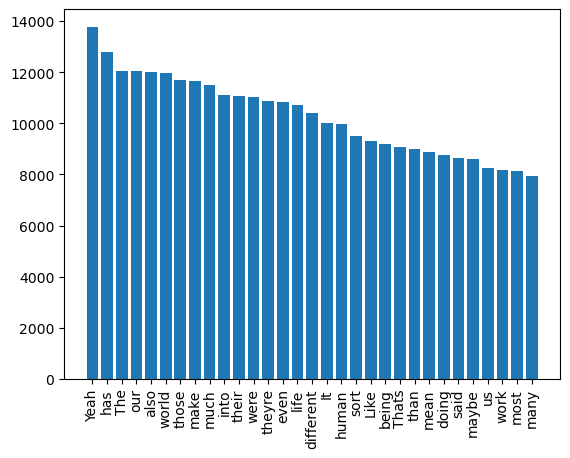

```python
# 30 most common words
most_common_words = sorted_word_counts[30:61]

# words and frequencies into lists to plot
words = [x[0] for x in most_common_words]
frequencies = [x[1] for x in most_common_words]
plt.bar(words, frequencies)
plt.xticks(rotation=90)
plt.show()
```

That's actually much better so lets do this save process but change out most_common_words

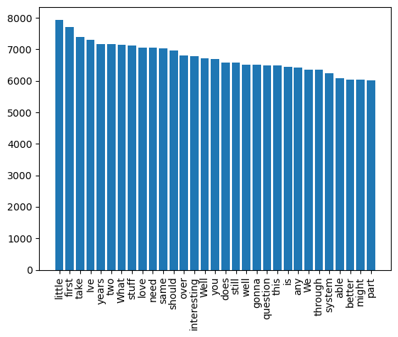

```python
#  most common words
most_common_words = sorted_word_counts[61:92]

# words and frequencies into lists to plot
words = [x[0] for x in most_common_words]
frequencies = [x[1] for x in most_common_words]
plt.bar(words, frequencies)
plt.xticks(rotation=90)
plt.show()
```

Lets try one more time and increase the slice this time just to save some time

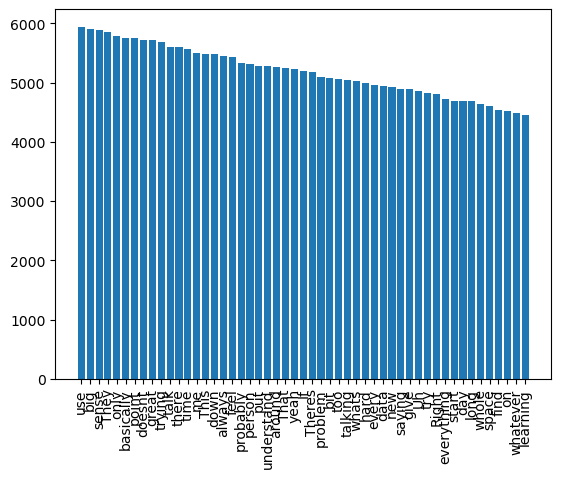

```python
# most common words
most_common_words = sorted_word_counts[93:144]

# words and frequencies into lists to plot
words = [x[0] for x in most_common_words]
frequencies = [x[1] for x in most_common_words]
plt.bar(words, frequencies)
plt.xticks(rotation=90)
plt.show()
```

That actually looks a lot better, but lets reduce it back to about 30.

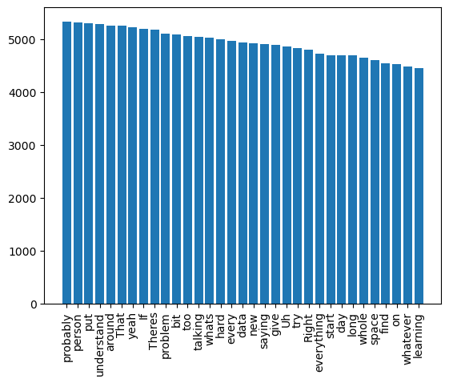

```python
# most common words
most_common_words = sorted_word_counts[111:144]

# words and frequencies into lists to plot
words = [x[0] for x in most_common_words]
frequencies = [x[1] for x in most_common_words]
plt.bar(words, frequencies)
plt.xticks(rotation=90)
plt.show()
```

And then one more time here for the next set

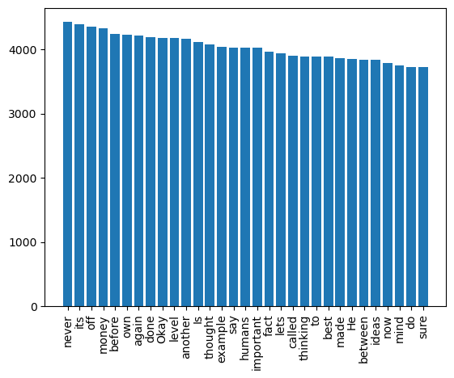

```python
# most common words
most_common_words = sorted_word_counts[144:175]

# words and frequencies into lists to plot
words = [x[0] for x in most_common_words]
frequencies = [x[1] for x in most_common_words]
plt.bar(words, frequencies)
plt.xticks(rotation=90)
plt.show()
```

Lets check the most commmon words now just by printing them.

```python
with open('filtered_text.txt', 'r') as f:
  text = f.read()

words = text.split()

from collections import Counter
word_counts = Counter(words)

most_common_words = word_counts.most_common(400)
```

```python
print(most_common_words)
```

```
[('And', 56255), ('So', 54830), ('know', 47476), ('people', 34999), ('theres', 26088), ('But', 23698), ('kind', 23545), ('an', 22435), ('things', 21491), ('very', 21198), ('way', 19863), ('more', 19502), ('it', 19235), ('um', 18789), ('uh', 17951), ('that', 17817), ('thing', 17772), ('which', 17751)…
```

We could use the 1000 most common words but as mentioned prior we could run into some risks as we see here that some of those are key areas for this podcast

```python
import codecs

with codecs.open('tweets.txt', 'r', encoding='utf-8') as f:
    text = f.read()

import re

# Lowercase the text and remove punctuation
text = text.lower()
text = re.sub(r'[^\w\s]', '', text)

# Split the text into words
words = text.split()

from sklearn.feature_extraction.text import TfidfVectorizer

# Create a TfidfVectorizer object
vectorizer = TfidfVectorizer()

# Compute the TF-IDF of the text
tfidf = vectorizer.fit_transform([text])

# Get the words with the highest TF-IDF scores
scores = zip(vectorizer.get_feature_names(), tfidf.data)
sorted_scores = sorted(scores, key=lambda x: x[1], reverse=True)

# Print the top 100 key topics
for word, score in sorted_scores[:100]:
    print(word)
```

```
ча
zusa
zuko
zombie
zoned
zork
zz
zoologist
zeroed
yellowing
yuron
yangs
youtubes
zhivago
zelikow
wrench
zimbabwe
zoos
workhorse
yummy
yen
yucca
zig
zippers
zigged
zombies
yearspirer
yitzhar
zygotes
yourselves
yemeni
zeldas
zaparizia
zoology
zebrafish
writes
yesterday
yassky
zealots
yeahthe
```

[output cut: 45 more lines]

```
zip
yunus
yielded
yazidis
xpbased
wisdom
zack
yerick
zooks
yorkers
yarn
yokosuka
zero
zodiacs
yeezy
```

and then for fun lets do some training for language modeling. I'm not going to run this because it will take too long frankly. convert this to a python cell and run it if curious.